# Seventh Week: Generalized Linear Models

Murder or suicide

Aida Ramezani 95105595

2018-04-28 00:10:42

۱.متغیر های بدون حشو انتحاب شده عبارت اند از :

```
##  [1] "ActivityCode"                   "DayOfWeekOfDeath"
##  [3] "Education2003Revision"          "HispanicOriginRaceRecode"
##  [5] "PlaceOfInjury"                  "PlaceOfDeathAndDecedentsStatus"
##  [7] "MannerOfDeath"                  "Race"
##  [9] "Age"                            "MethodOfDisposition"
## [11] "BinaryGender"                   "factorMaritualStatus"
```

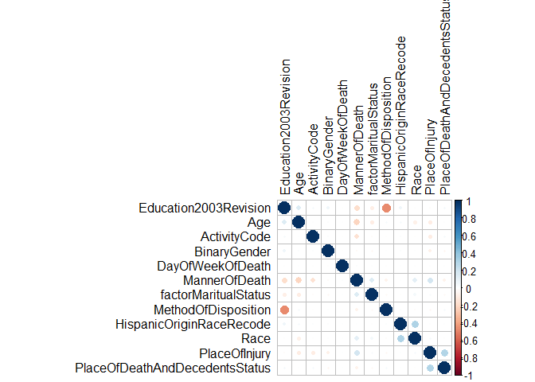

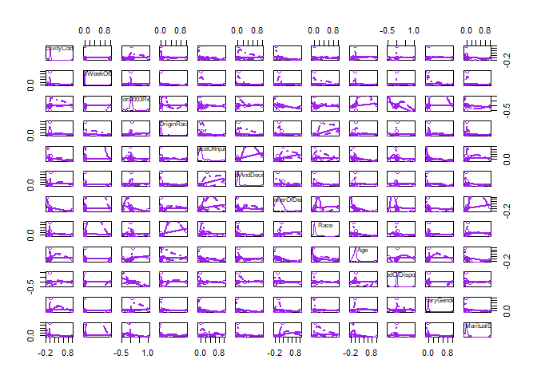

با توجه به این که تمامی پارامتر ها کیفی هستند، از آزمون فرض استقلال خی دو استفاده شده است. به جز پارامتر سن که از تی تست استفاده شده است.

```
##
##  Pearson's Chi-squared test with Yates' continuity correction
##
## data:  death_data_selected$BinaryGender and death_data_selected$isSuicide
## X-squared = 24.044, df = 1, p-value = 9.417e-07
```

```
##
##  Pearson's Chi-squared test
##
## data:  death_data_selected$Race and death_data_selected$isSuicide
## X-squared = 15338, df = 13, p-value < 2.2e-16
```

```
##
##  Pearson's Chi-squared test
##
## data:  death_data_selected$Education2003Revision and death_data_selected$isSuicide
## X-squared = 3572.9, df = 9, p-value < 2.2e-16
```

```
##
##  Welch Two Sample t-test
##
## data:  death_data_selected$Age and death_data_selected$isSuicide
## t = 423.77, df = 60016, p-value < 2.2e-16
## alternative hypothesis: true difference in means is not equal to 0
## 95 percent confidence interval:
##  43.2347 43.6365
## sample estimates:
##  mean of x  mean of y
## 44.1548375  0.7192351
```

```
##
##  Pearson's Chi-squared test
##
## data:  death_data_selected$MethodOfDisposition and death_data_selected$isSuicide
## X-squared = 4460.4, df = 6, p-value < 2.2e-16
```

با توجه به پی-مقدار های به دست آمده برای متغیر ها، مدل نقص یابی شده و در آخر به مدل نهایی میرسیم.

```
##
## Call:
## glm(formula = isSuicide ~ Race + Age + BinaryGender + MethodOfDisposition +
##     Education2003Revision, family = "binomial", data = death_data_selected)
##
## Deviance Residuals:
##     Min       1Q   Median       3Q      Max
## -8.4904  -1.0499   0.5771   0.8056   2.3109
##
## Coefficients:
##                         Estimate Std. Error z value Pr(>|z|)
## (Intercept)           -1.6055543  0.0381293  -42.11   <2e-16 ***
## Race                  -0.1291328  0.0060083  -21.49   <2e-16 ***
## Age                    0.0300561  0.0005748   52.28   <2e-16 ***
## BinaryGender          -0.0004832  0.0239274   -0.02    0.984
## MethodOfDisposition    0.2207819  0.0065400   33.76   <2e-16 ***
## Education2003Revision  0.3326696  0.0076441   43.52   <2e-16 ***
## ---
## Signif. codes:  0 '***' 0.001 '**' 0.01 '*' 0.05 '.' 0.1 ' ' 1
##
## (Dispersion parameter for binomial family taken to be 1)
##
##     Null deviance: 71216  on 59978  degrees of freedom
## Residual deviance: 63485  on 59973  degrees of freedom
## AIC: 63497
##
## Number of Fisher Scoring iterations: 25
```

```
##
## Call:
## glm(formula = isSuicide ~ Race + Age + DayOfWeekOfDeath + MethodOfDisposition +
##     Education2003Revision, family = "binomial", data = death_data_selected)
##
## Deviance Residuals:
##     Min       1Q   Median       3Q      Max
## -8.4904  -1.0522   0.5769   0.8060   2.3153
##
## Coefficients:
##                         Estimate Std. Error z value Pr(>|z|)
## (Intercept)           -1.5624868  0.0426132 -36.667   <2e-16 ***
## Race                  -0.1291062  0.0060078 -21.490   <2e-16 ***
## Age                    0.0300548  0.0005748  52.287   <2e-16 ***
## DayOfWeekOfDeath      -0.0108325  0.0048276  -2.244   0.0248 *
## MethodOfDisposition    0.2206615  0.0065316  33.783   <2e-16 ***
## Education2003Revision  0.3325883  0.0076226  43.632   <2e-16 ***
## ---
## Signif. codes:  0 '***' 0.001 '**' 0.01 '*' 0.05 '.' 0.1 ' ' 1
##
## (Dispersion parameter for binomial family taken to be 1)
##
##     Null deviance: 71216  on 59978  degrees of freedom
## Residual deviance: 63456  on 59973  degrees of freedom
## AIC: 63468
##
## Number of Fisher Scoring iterations: 11
```

```
##
## Call:
## glm(formula = isSuicide ~ ActivityCode + Race + Age + MethodOfDisposition +
##     Education2003Revision + PlaceOfInjury + PlaceOfDeathAndDecedentsStatus +
##     factorMaritualStatus, family = "binomial", data = death_data_selected)
##
## Deviance Residuals:
##     Min       1Q   Median       3Q      Max
## -7.4675  -0.8541   0.5219   0.7628   3.2924
##
## Coefficients:
##                                  Estimate Std. Error z value Pr(>|z|)
## (Intercept)                    -5.5537895  0.1744583  -31.83   <2e-16 ***
## ActivityCode                    0.5143259  0.0184046   27.95   <2e-16 ***
## Race                           -0.1223863  0.0060800  -20.13   <2e-16 ***
## Age                             0.0270543  0.0005877   46.03   <2e-16 ***
## MethodOfDisposition             0.2041341  0.0067093   30.43   <2e-16 ***
## Education2003Revision           0.3160561  0.0078031   40.50   <2e-16 ***
## PlaceOfInjury                  -0.1170927  0.0029918  -39.14   <2e-16 ***
## PlaceOfDeathAndDecedentsStatus  0.1012680  0.0050682   19.98   <2e-16 ***
## factorMaritualStatus           -0.2214527  0.0109587  -20.21   <2e-16 ***
## ---
## Signif. codes:  0 '***' 0.001 '**' 0.01 '*' 0.05 '.' 0.1 ' ' 1
##
## (Dispersion parameter for binomial family taken to be 1)
##
##     Null deviance: 71216  on 59978  degrees of freedom
## Residual deviance: 60149  on 59970  degrees of freedom
## AIC: 60167
##
## Number of Fisher Scoring iterations: 5
```

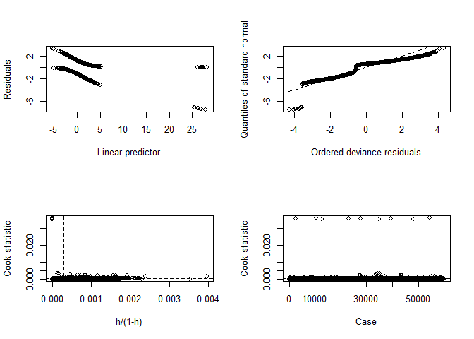

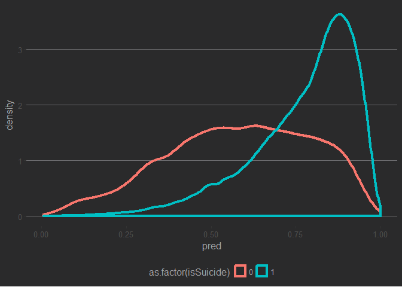

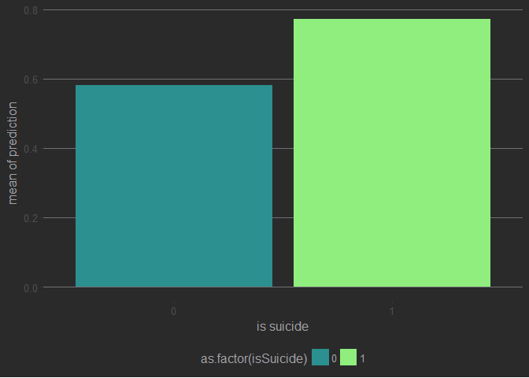

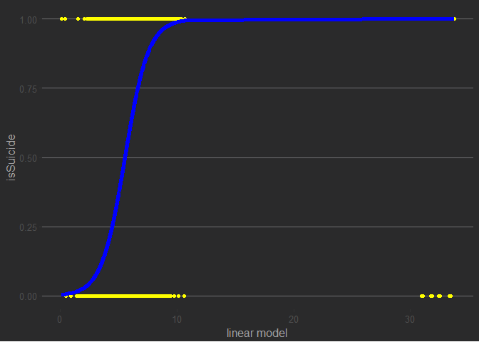

```
## [1] "Positive samples:  10197"
```

```
## [1] "Negative samples:  1799"
```

```
## [1] "true positive:  7927"
```

```
## [1] "true negative:  1196"
```

```
## [1] "false positive:  603"
```

```
## [1] "false negative:  2270"
```

[output not shown]

```
## [1] "Accuracy:  0.760503501167056"
```

```
## [1] "true positive rate:  0.777385505540845"
```

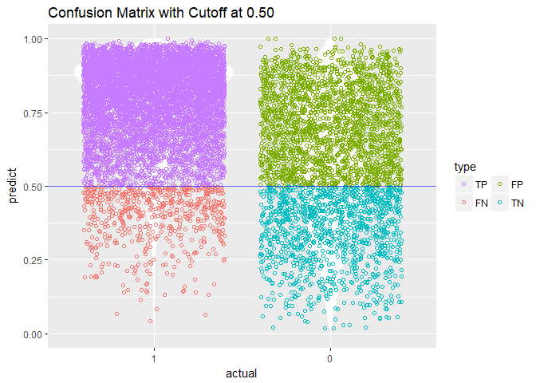

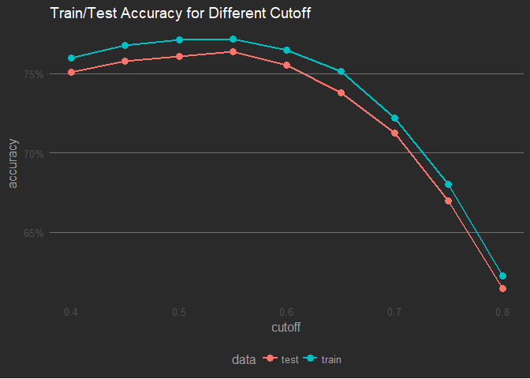

```
## [1] "cut off 0.55"
```

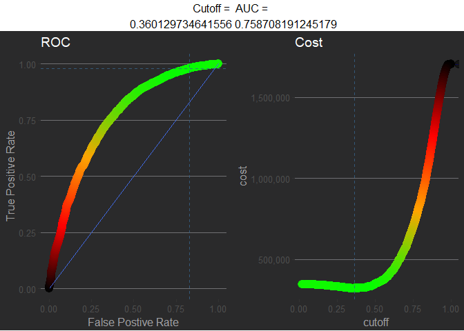

```
## [1] "cutoff:  0.360129734641556"
```

[output not shown]

[output not shown]

[output not shown]

```
## Model Details:
## ==============
##
## H2OBinomialModel: glm
## Model ID:  GLM_model_R_1524858227206_1
## GLM Model: summary
##     family  link                                regularization
## 1 binomial logit Elastic Net (alpha = 0.5, lambda = 1.956E-4 )
##   number_of_predictors_total number_of_active_predictors
## 1                          8                           8
##   number_of_iterations      training_frame
## 1                    4 death_data_selected
##
## Coefficients: glm coefficients
##                            names coefficients standardized_coefficients
## 1                      Intercept    -5.531799                  1.151388
## 2                   ActivityCode     0.512698                  0.294664
## 3          Education2003Revision     0.314704                  0.559473
## 4                  PlaceOfInjury    -0.116800                 -0.394268
## 5 PlaceOfDeathAndDecedentsStatus     0.100861                  0.197537
## 6                           Race    -0.121978                 -0.185301
## 7                            Age     0.026997                  0.677588
## 8            MethodOfDisposition     0.203043                  0.358850
## 9           factorMaritualStatus    -0.220924                 -0.219463
##
## H2OBinomialMetrics: glm
## ** Reported on training data. **
##
## MSE:  0.1618344
## RMSE:  0.4022865
## LogLoss:  0.501415
## Mean Per-Class Error:  0.3704452
## AUC:  0.7667823
## Gini:  0.5335646
## R^2:  0.1985855
## Residual Deviance:  60148.74
## AIC:  60166.74
##
## Confusion Matrix (vertical: actual; across: predicted) for F1-optimal threshold:
##           0     1    Error          Rate
```

[output cut: 67 more lines]

```
## ---
##                         mean           sd cv_1_valid cv_2_valid cv_3_valid
## precision          0.7744505  0.005784949 0.78883106 0.76547295  0.7774829
## r2                0.19818585 0.0044203047 0.20546407 0.19798079 0.20431639
## recall             0.9545228 0.0048560533  0.9526749   0.958018  0.9451613
## residual_deviance  12035.662     113.5963  11744.656 12050.2705  12020.099
## rmse              0.40236887 0.0021890055  0.3970497 0.40481606 0.40173575
## specificity       0.28779387   0.01916592 0.32043862  0.2682783 0.31405202
##                   cv_4_valid cv_5_valid
## precision          0.7691182  0.7713472
## r2                0.19455248  0.1886155
## recall            0.96554893   0.951211
## residual_deviance  12206.951  12156.333
## rmse               0.4022384 0.40600443
## specificity        0.2485859 0.28761455
```

۹. آیا ما میتوانیم سرویسی به قضات ارایه کنیم تا با استفاده از اطلاعات مرگ بتوانند موارد مشکوک به قتل را از خودکشی تفکیک دهند؟  
با توجه به این نکته که در داده مورد نظر، اطلاعاتی از قبیل وضعیت مالی، میزان موفقیت در شغل، میزان موفقیت در تحصیلات، تعداد اعضای خانواده که فرد با آن ها زندگی میکند، داده نشده اند، قضاوت بر اساس مواردی مانند سن، نژاد و سایر پارامتر های گفته شده میباشد. این اطلاعات برای قضاوت کردن کافی نمیباشد.  
البته قضاوت کردن نباید فقط بر اساس مدل ارائه شده باشد زیرا هر چقد هم که مدل دقیق باشد هرگز نمیتوان به خطای 0 رسید در نتیجه این ابزار تنها میتواند به قضات در تصمیم گیری کمک کند. در این مدل نیز با توجه به سوال قبل میتوان نتیجه گرفت که دقت آن به اندازه کافی بالا نیست.  
البته لازم به ذکر است که مدلی برای تشخیص خودکشی در کشور آمریکا ارائه شده است.